# Calling C from R

James Henderson, PhD

June 30, 2017

Back to main page.

## Calling C from R

Before getting into Rcpp examples, we will review how to incorporate compiled code into **R** as detailed in the [R manual](https://cran.r-project.org/doc/manuals/r-release/R-exts.html#Interface-functions-_002eC-and-_002eFortran).

#### Overview

The key steps are:

0. Write some C code.
1. Compile the code using `R CMD SHLIB`.
2. Write an R function to call that code using `.C()` or `.Call()`.
3. Load the compiled library using `dyn.load()`.

#### C functions for R

When writing C functions for R keep in mind the following:

0. Objects in these languages need to be declared before use.
1. The return type should always be `void`. Results can be passed back to R by modifying an object created in R for this purpose.
2. Vectors in **C** and **C++** are indexed from 0.
3. Lines should be ended with a semi-colon `;`

#### Compilation

The shell command `R CMD SHLIB myFuncC.c` first **compiles** the **C** code in `myFuncC.c` creating `myFuncC.o` and then makes it accessible to **R** through a shared library `myFuncC.so`.

When compiled within a package all functions in the `/src` directory will share a single shared library `pkg.so`.

#### R wrappers for calls to C

Compiled **C** functions can be called from **R** using `.C() or`.Call()`. All such calls should be wrapped within an **R** function (of the same name) in order to handle error checking, type conversion, return values, etc.

#### Example

As an example, we will compare the performance of two functions for computing Fibonocci numbers $x_n = x_{n-1} + x_{n-2}$ :
$$\{x_n\}_{n=1} = 1, 1, 2, 3, 5, 8, 13, 21, ...$$
The source code for these examples is in:

- Fib.R
- FibC.R
- C_FibC.c

```r
library(microbenchmark)
source('./examples/Fib.R')
source('./examples/FibC.R')
dyn.load('examples/C_FibC.so')
Fib(10)
```

```
##  [1]  1  1  2  3  5  8 13 21 34 55
```

```r
FibC(10)
```

```
##  [1]  1  1  2  3  5  8 13 21 34 55
```

```r
FibBenchMark = microbenchmark(Fib(100),FibC(100),FibC_noCoerce(100))
print(FibBenchMark,order='median',digits=3)
```

```
## Unit: microseconds
##                expr   min    lq mean median    uq    max neval
##  FibC_noCoerce(100)  1.72  1.98 45.4   2.10  2.28 4287.0   100
##           FibC(100)  1.77  2.13 44.8   2.32  2.57 4226.9   100
##            Fib(100) 10.07 10.61 12.3  11.42 11.98   69.7   100
```

```r
options(microbenchmark.unit="relative")
print(FibBenchMark,order='median',digits=3)
```

```
## Unit: relative
##                expr  min   lq  mean median   uq    max neval
##  FibC_noCoerce(100) 1.00 1.00 1.000   1.00 1.00 1.0000   100
##           FibC(100) 1.03 1.07 0.986   1.10 1.12 0.9860   100
##            Fib(100) 5.84 5.35 0.272   5.43 5.25 0.0163   100
```

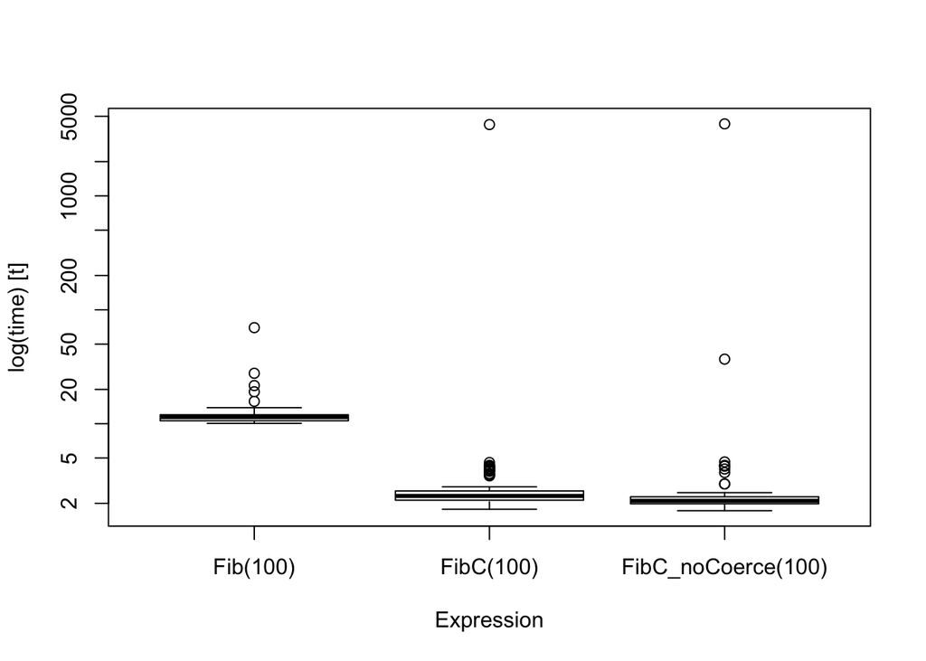

```r
boxplot(FibBenchMark)
```

### Exercises

0. Login to one of the ITS servers using a shell application:

> ssh mario.dsc.umich.edu

or

> ssh luigi.dsc.umich.edu
1. Download the workshop files using git:

> git clone https://github.com/jbhender/Intro_to_Rcpp/

and move to the `exmaples` folder

> cd Intro_to_Rcpp/examples/
2. Compile to a shared object using:

> R CMD SHLIB FibC.c
3. Open R and use `source` to read FibFunc.R into the workspace. Call `FibFunc(10)` and observe the error message.
4. Load the shared object into R and call `FibFunc(10)` again:

> dyn.load(‘Fibonacci.so’)

Back to main page.